# R Notebook

```r
library(readr)
library(dplyr)
library(mice)
library(caret)
library(DescTools)
```

Sources Referenced: - https://www.r-bloggers.com/2015/10/imputing-missing-data-with-r-mice-package/ - https://www.gerkovink.com/miceVignettes/

Steps:

- 5 Number Summary + Outlier Detection
- Deal with Outliers:
  - keep if a part of the data
  - if not apart of data population, remove
  - if error, try to fix (0 values and outliers)
  - Winsorize
- Transform
- Impute

https://cran.r-project.org/mirrors.html

```r
test <- read_csv("..\\data\\moneyball-evaluation-data.csv")
train <- read_csv("..\\data\\moneyball-training-data.csv")
```

```r
summary(train)
```

```
     INDEX         TARGET_WINS     TEAM_BATTING_H TEAM_BATTING_2B TEAM_BATTING_3B  TEAM_BATTING_HR
 Min.   :   1.0   Min.   :  0.00   Min.   : 891   Min.   : 69.0   Min.   :  0.00   Min.   :  0.00
 1st Qu.: 630.8   1st Qu.: 71.00   1st Qu.:1383   1st Qu.:208.0   1st Qu.: 34.00   1st Qu.: 42.00
 Median :1270.5   Median : 82.00   Median :1454   Median :238.0   Median : 47.00   Median :102.00
 Mean   :1268.5   Mean   : 80.79   Mean   :1469   Mean   :241.2   Mean   : 55.25   Mean   : 99.61
 3rd Qu.:1915.5   3rd Qu.: 92.00   3rd Qu.:1537   3rd Qu.:273.0   3rd Qu.: 72.00   3rd Qu.:147.00
 Max.   :2535.0   Max.   :146.00   Max.   :2554   Max.   :458.0   Max.   :223.00   Max.   :264.00

 TEAM_BATTING_BB TEAM_BATTING_SO  TEAM_BASERUN_SB TEAM_BASERUN_CS TEAM_BATTING_HBP TEAM_PITCHING_H
 Min.   :  0.0   Min.   :   0.0   Min.   :  0.0   Min.   :  0.0   Min.   :29.00    Min.   : 1137
 1st Qu.:451.0   1st Qu.: 548.0   1st Qu.: 66.0   1st Qu.: 38.0   1st Qu.:50.50    1st Qu.: 1419
 Median :512.0   Median : 750.0   Median :101.0   Median : 49.0   Median :58.00    Median : 1518
 Mean   :501.6   Mean   : 735.6   Mean   :124.8   Mean   : 52.8   Mean   :59.36    Mean   : 1779
 3rd Qu.:580.0   3rd Qu.: 930.0   3rd Qu.:156.0   3rd Qu.: 62.0   3rd Qu.:67.00    3rd Qu.: 1682
 Max.   :878.0   Max.   :1399.0   Max.   :697.0   Max.   :201.0   Max.   :95.00    Max.   :30132
                 NA's   :102      NA's   :131     NA's   :772     NA's   :2085
 TEAM_PITCHING_HR TEAM_PITCHING_BB TEAM_PITCHING_SO  TEAM_FIELDING_E  TEAM_FIELDING_DP
 Min.   :  0.0    Min.   :   0.0   Min.   :    0.0   Min.   :  65.0   Min.   : 52.0
 1st Qu.: 50.0    1st Qu.: 476.0   1st Qu.:  615.0   1st Qu.: 127.0   1st Qu.:131.0
 Median :107.0    Median : 536.5   Median :  813.5   Median : 159.0   Median :149.0
 Mean   :105.7    Mean   : 553.0   Mean   :  817.7   Mean   : 246.5   Mean   :146.4
 3rd Qu.:150.0    3rd Qu.: 611.0   3rd Qu.:  968.0   3rd Qu.: 249.2   3rd Qu.:164.0
 Max.   :343.0    Max.   :3645.0   Max.   :19278.0   Max.   :1898.0   Max.   :228.0
                                   NA's   :102                        NA's   :286
```

```r
boxplot(train)$out
```

[output not shown]

[output cut: 42 more lines]

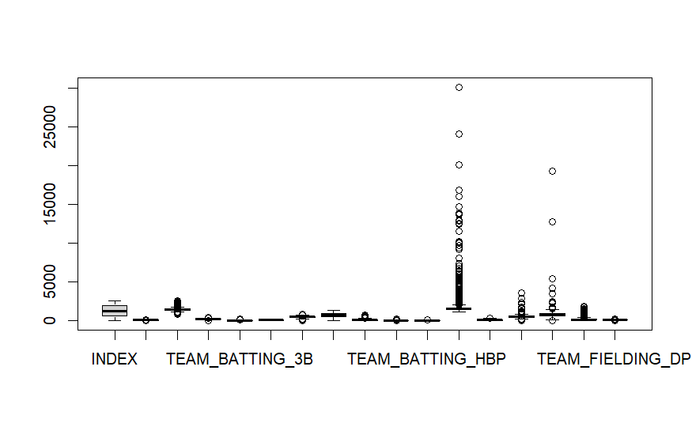

```r
text(colnames(train), srt = 45, pos = 1, xpd = TRUE)
```

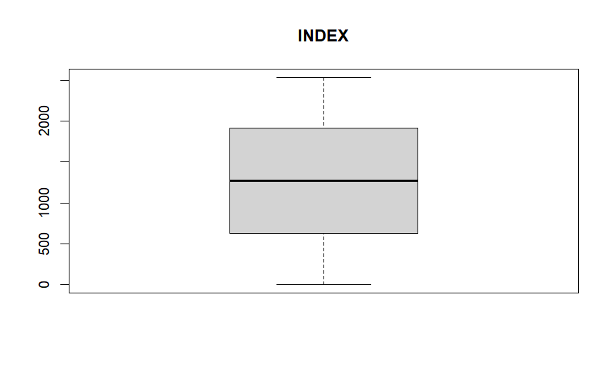

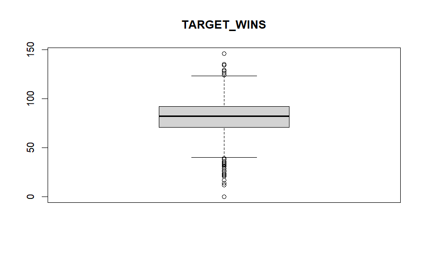

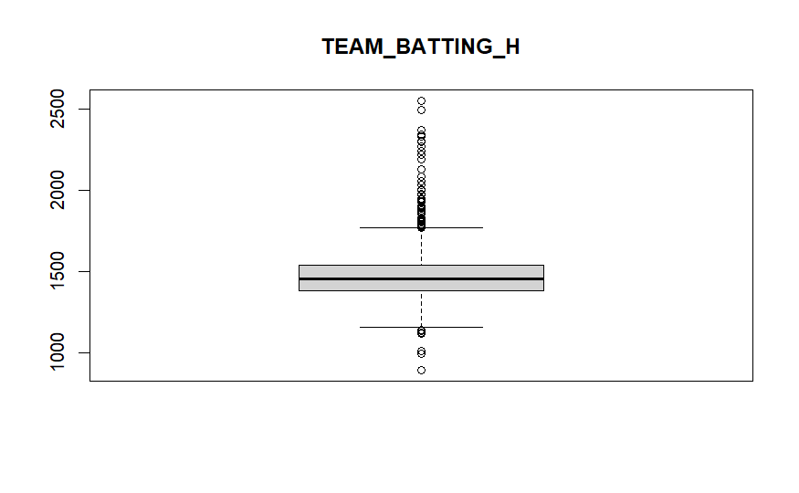

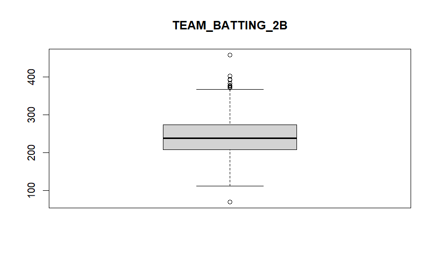

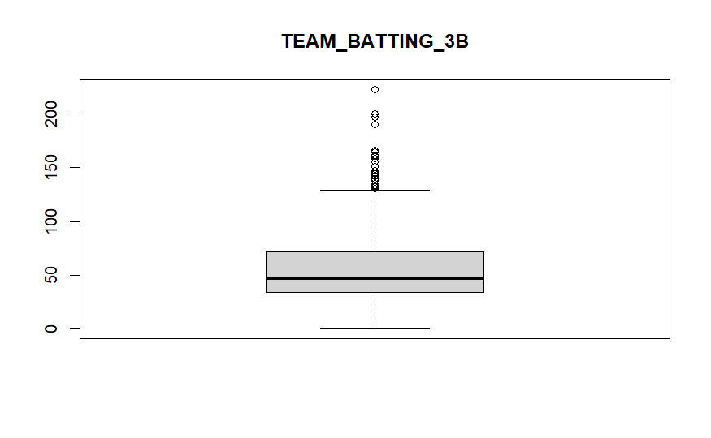

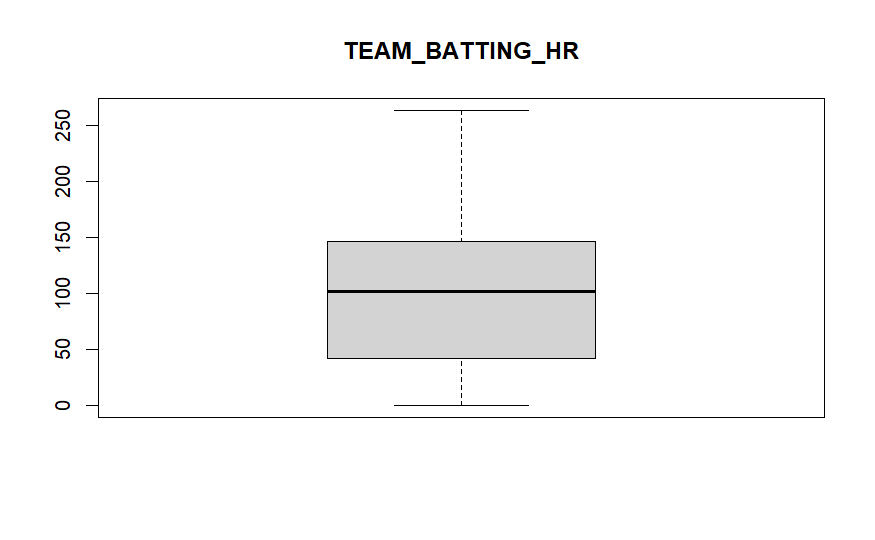

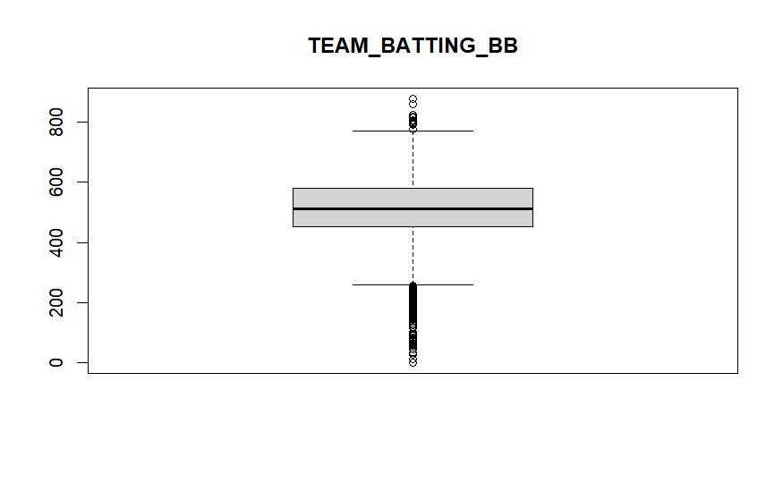

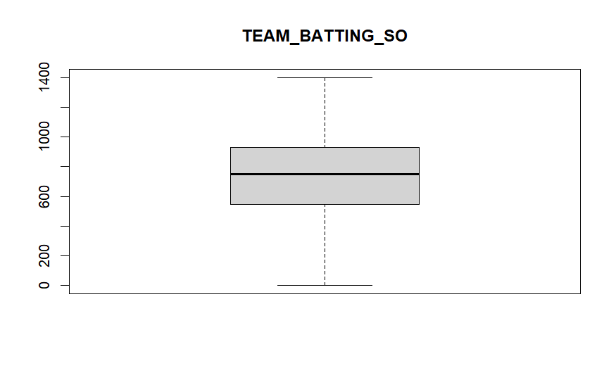

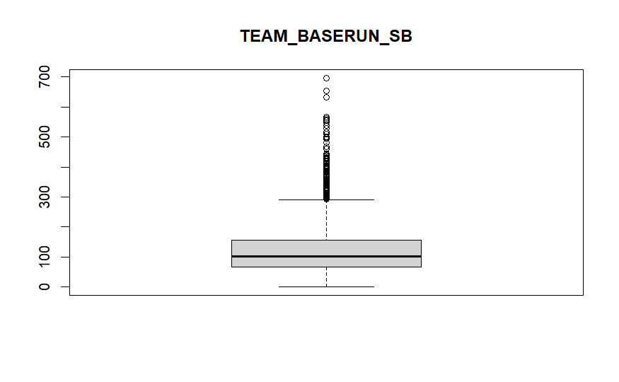

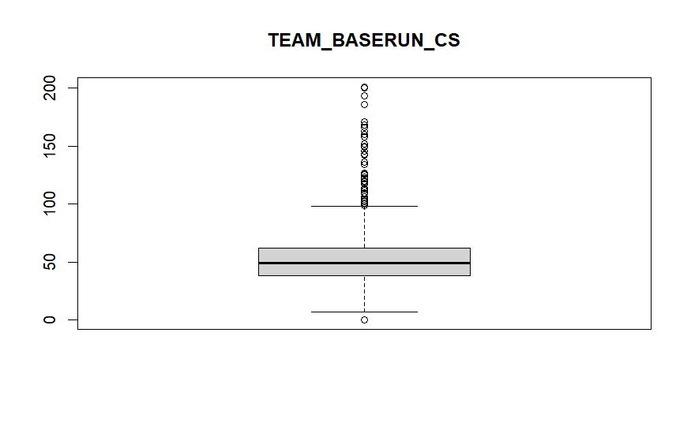

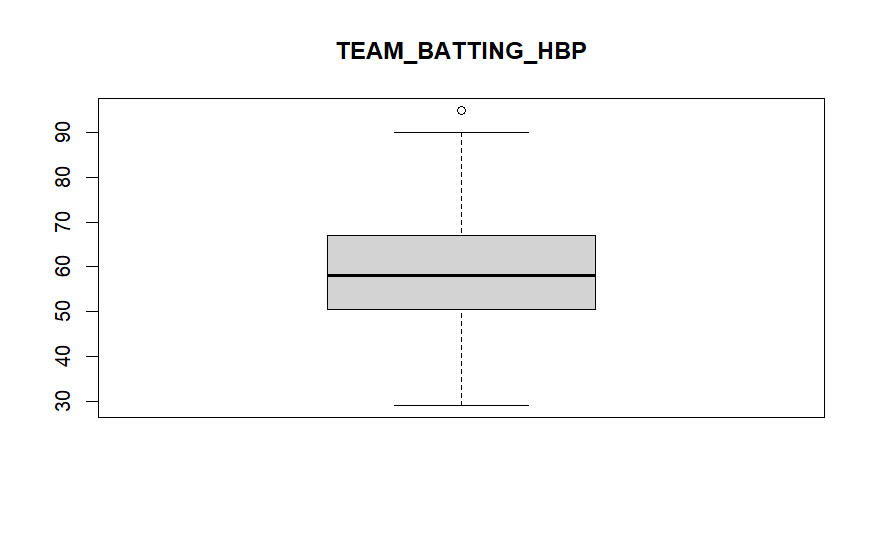

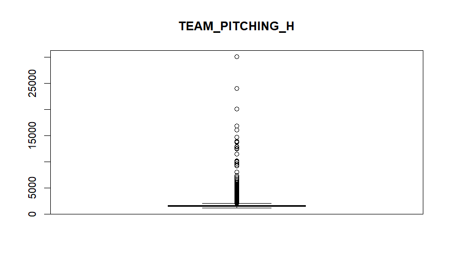

[5 more figures not shown]

```r
for (col_name in names(train)) {

  boxplot(train[[col_name]], main = col_name)

}
```

Missing completely at random (MCAR) when the missingness mechanism is completely independent of the estimate of our parameter(s) of interest. Deletion will yield unbiased results.

Missing at random (MAR) when the missingness mechanism is conditionally independent of the estimate of our parameter(s) of interest. In short, the data with complete cases are biased.

Missing not at random (MNAR) when the missingness mechanism is associated with the estimate of our parameter(s) of interest

```r
percentMiss <- function(x){sum(is.na(x))/length(x)*100} # Creates percentage of missing values

variable_pMiss <- apply(train,2,percentMiss) # 2 = runs on columns
sample_pMiss <- apply(train,1,percentMiss) # 1 = runs on rows
```

```r
variable_pMiss
```

```
           INDEX      TARGET_WINS   TEAM_BATTING_H  TEAM_BATTING_2B  TEAM_BATTING_3B  TEAM_BATTING_HR
        0.000000         0.000000         0.000000         0.000000         0.000000         0.000000
 TEAM_BATTING_BB  TEAM_BATTING_SO  TEAM_BASERUN_SB  TEAM_BASERUN_CS TEAM_BATTING_HBP  TEAM_PITCHING_H
        0.000000         4.481547         5.755712        33.919156        91.608084         0.000000
TEAM_PITCHING_HR TEAM_PITCHING_BB TEAM_PITCHING_SO  TEAM_FIELDING_E TEAM_FIELDING_DP
        0.000000         0.000000         4.481547         0.000000        12.565905
```

```r
sum(sample_pMiss > 50)
```

```
[1] 0
```

We can see that most variables have low percentage miss rates. Two variables TEAM_BATTING_HBP and TEAM_BASERUN_CS have 91.6% and 33.9% missing rates which leads to a recommendation to remove at least TEAM_BATTING_HBP from the dataset. Should TEAM_BASERUN_CS be removed for having more than 25% of observations missing its value?

```r
#Filters for instances where the entire row is NA
train <- train %>%
  filter(if_any(everything(), ~ !is.na(.))) #keep rows that have atleast one value that is not NA

#if_any : https://www.tidyverse.org/blog/2021/02/dplyr-1-0-4-if-any/
#         https://dplyr.tidyverse.org/reference/across.html
```

```r
#Filtering for instances where the entire column is NA

not_all_na <- function(x) any(!is.na(x))
# Create a function since where() only works with functions
# !is.na(x) returns a vector of T/F if it is not an NA value
# any() checks to see if any values in the vector are TRUE

train_cleaned <- train %>% select(where(not_all_na)) # Selects only columns that are not completely NA
```

```r
train_cleaned <- train_cleaned %>% select (-TEAM_BATTING_HBP, -INDEX)

colnames(train_cleaned) <- c("Wins","Bat_H","Bat_2B","Bat_3B","Bat_HR","Bat_BB", "Bat_SO","Base_SB","Base_CS","Pitch_H","Pitch_HR","Pitch_BB","Pitch_SO","Field_E","Field_DP")

train_cleaned <- as.data.frame(train_cleaned)
```

```r
Wins <- train_cleaned$Wins
train_winsor <- train_cleaned[-1] # removing wins to avoid winsorizing them

for (col in colnames(train_winsor[-1])) {
  train_winsor[[col]] <- Winsorize(train_winsor[[col]], na.rm = TRUE)
}

train_winsor <- data.frame(Wins,train_winsor)
```

## Checking Outliers and Distribution after Winsor

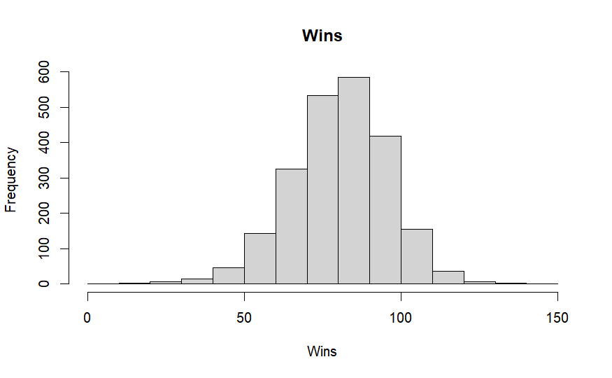

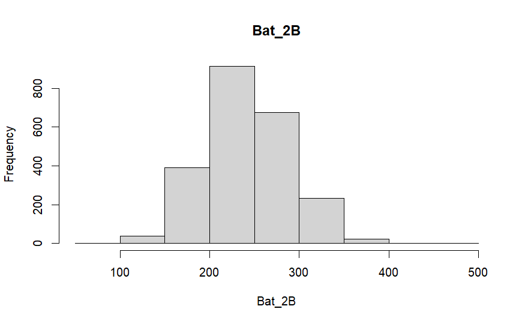

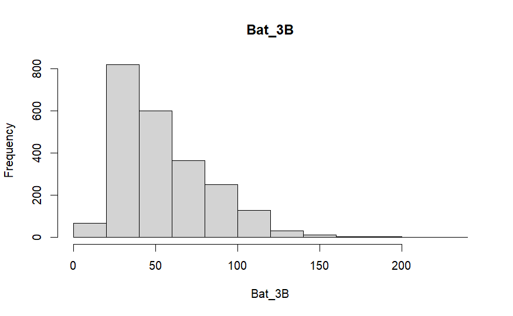

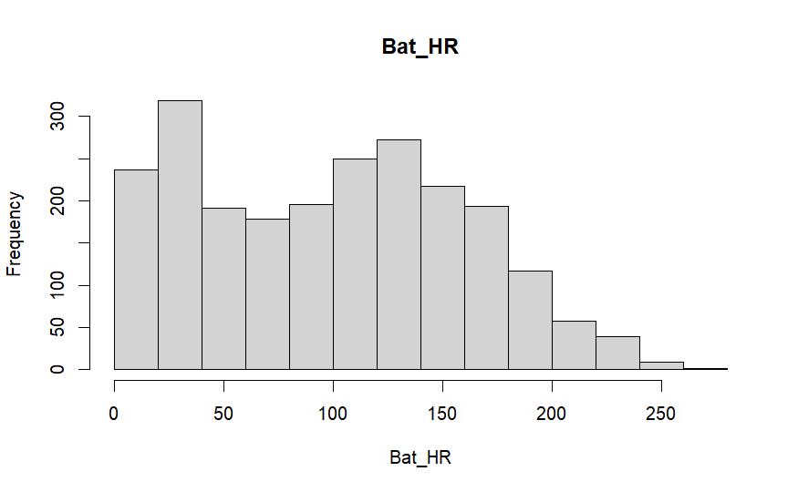

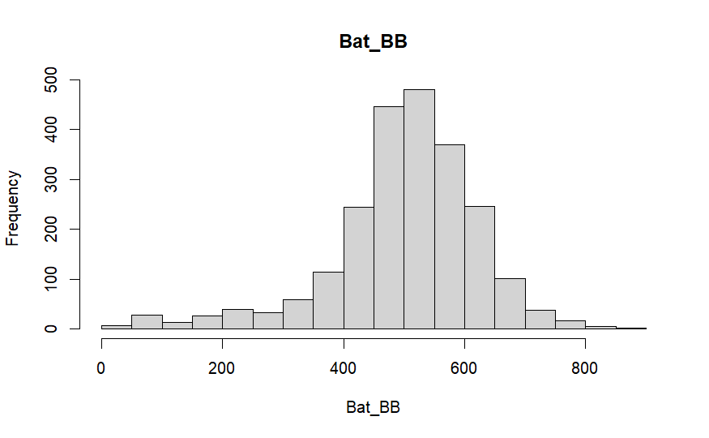

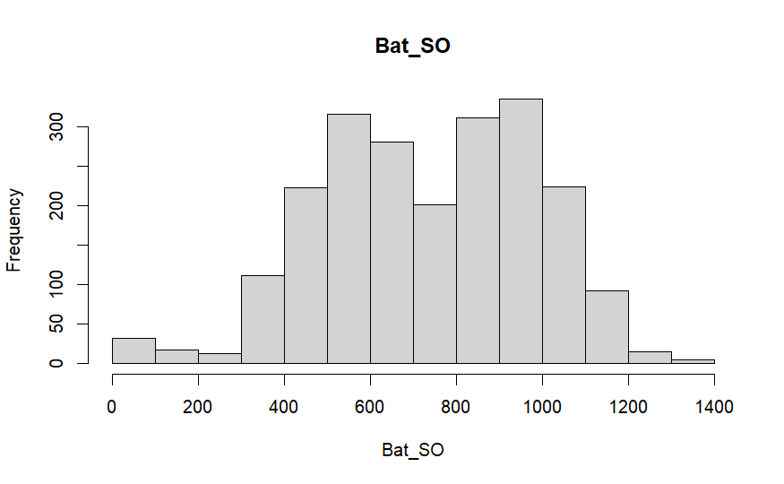

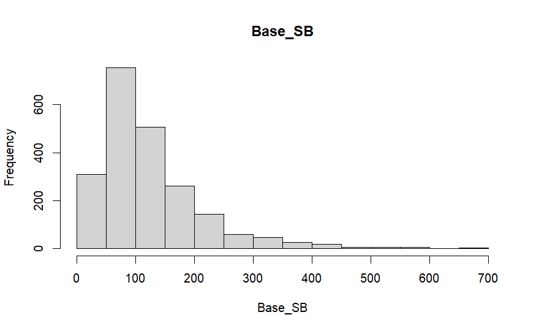

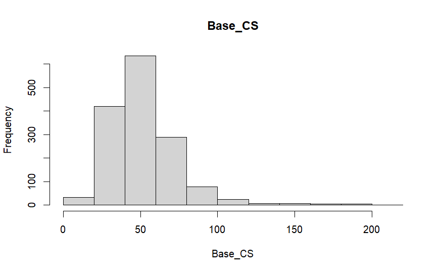

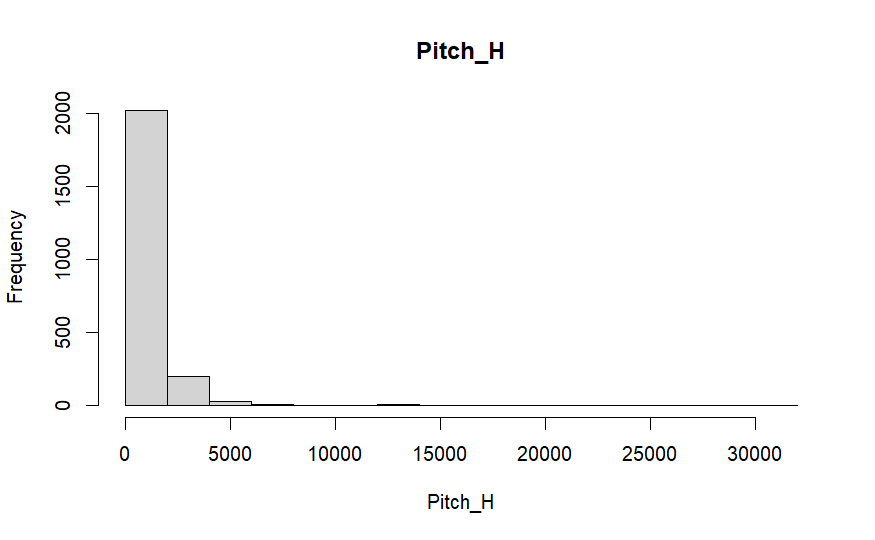

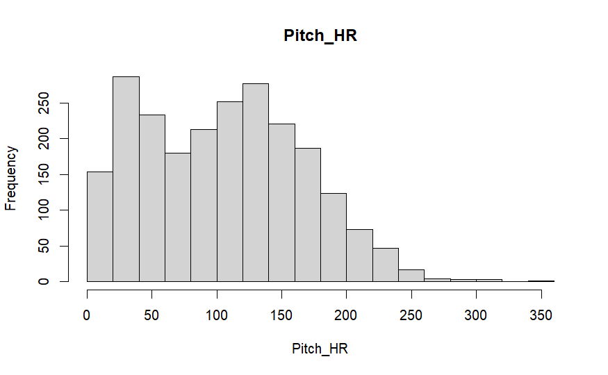

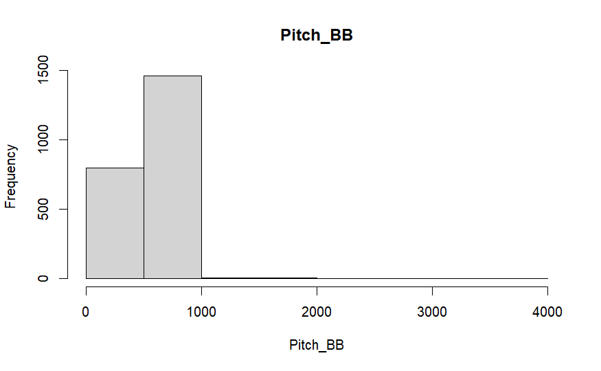

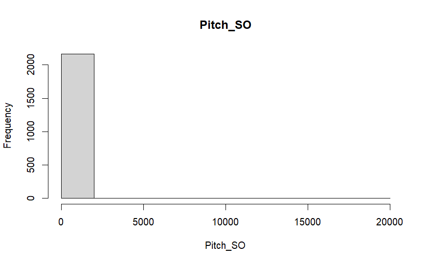

[1 more figures not shown]

```r
for (col_name in colnames(train_cleaned)) {
  hist(train_cleaned[[col_name]], main = col_name, xlab = col_name)
}
```

[figure not shown]

```r
NA
```

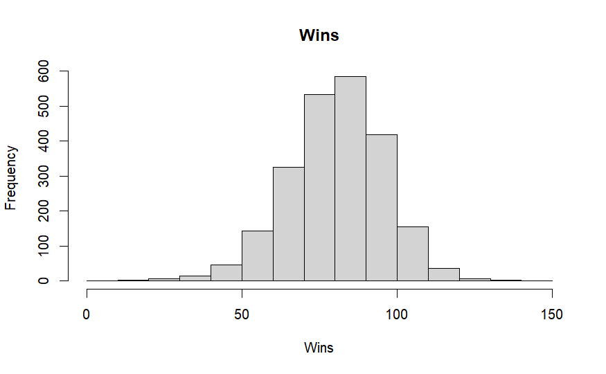

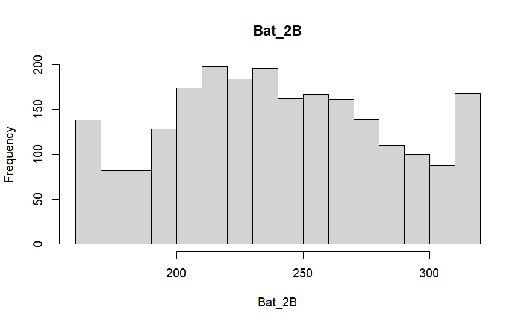

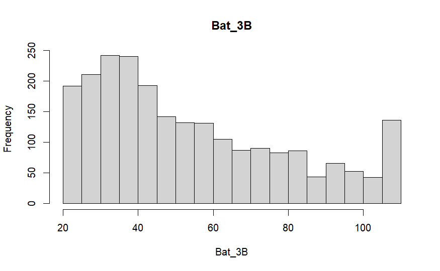

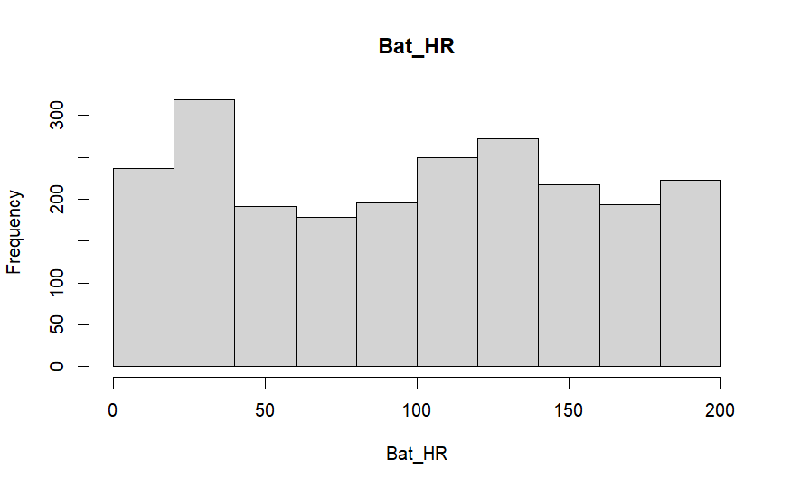

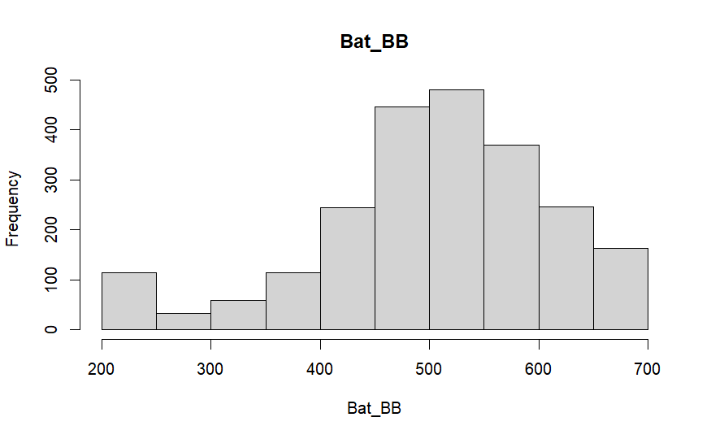

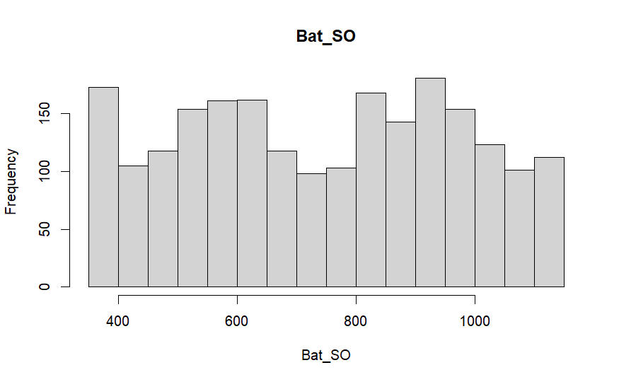

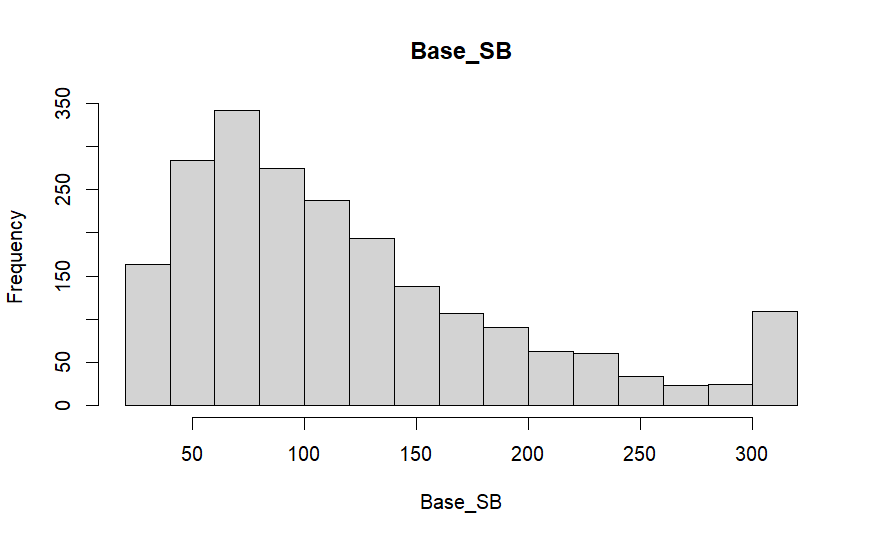

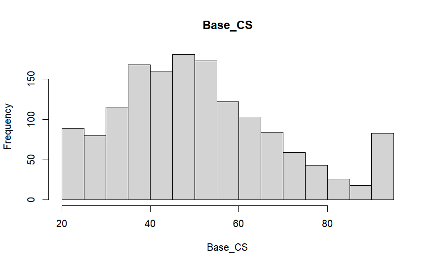

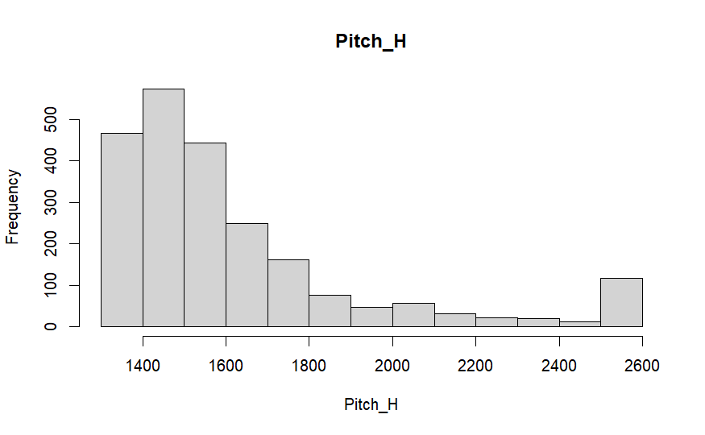

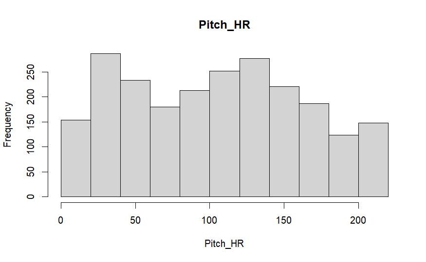

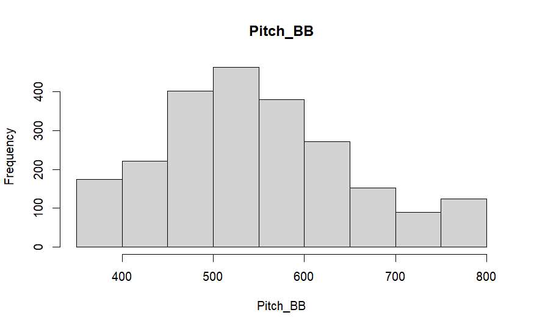

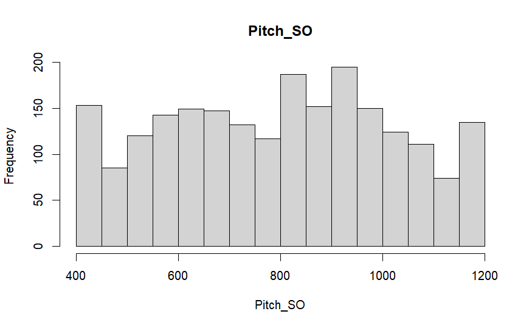

[2 more figures not shown]

```r
for (col_name in colnames(train_winsor)) {
  hist(train_winsor[[col_name]], main = col_name, xlab = col_name)
}
```

```r
# Checks impacts of Winsorizing the dataframe
# Pitch_H and Field_E still have many outliers

boxplot(train_winsor)$out
```

[output not shown]

[output cut: 51 more lines]

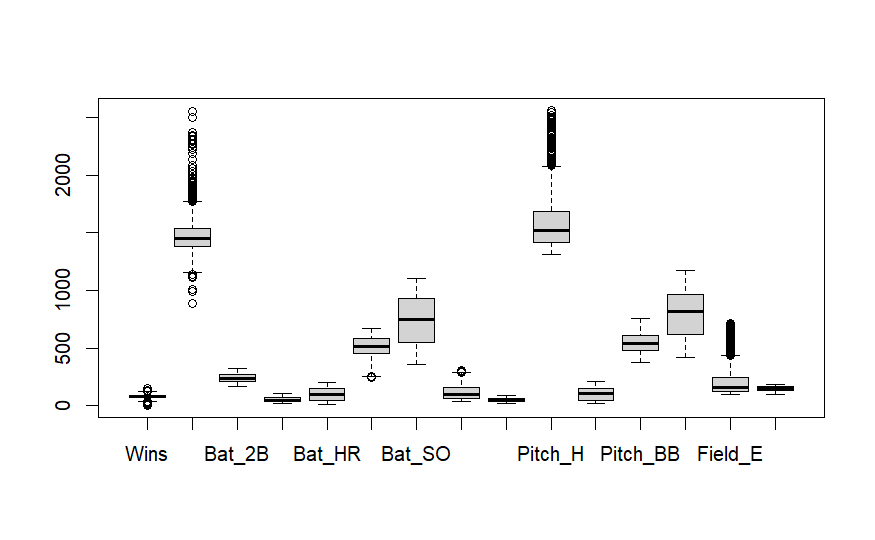

```r
text(colnames(train_winsor), srt = 45, pos = 1, xpd = TRUE)
```

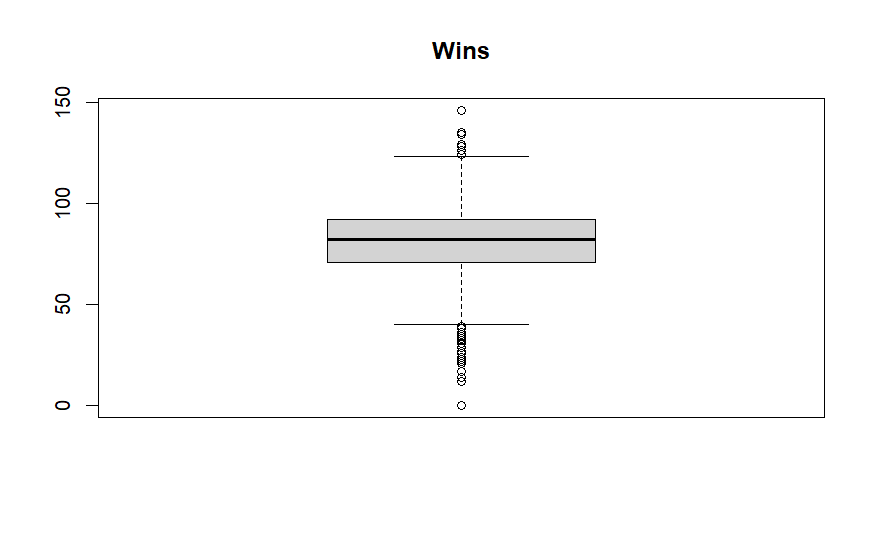

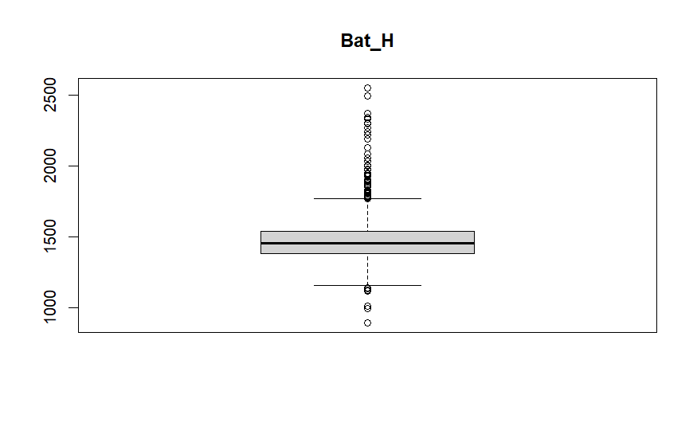

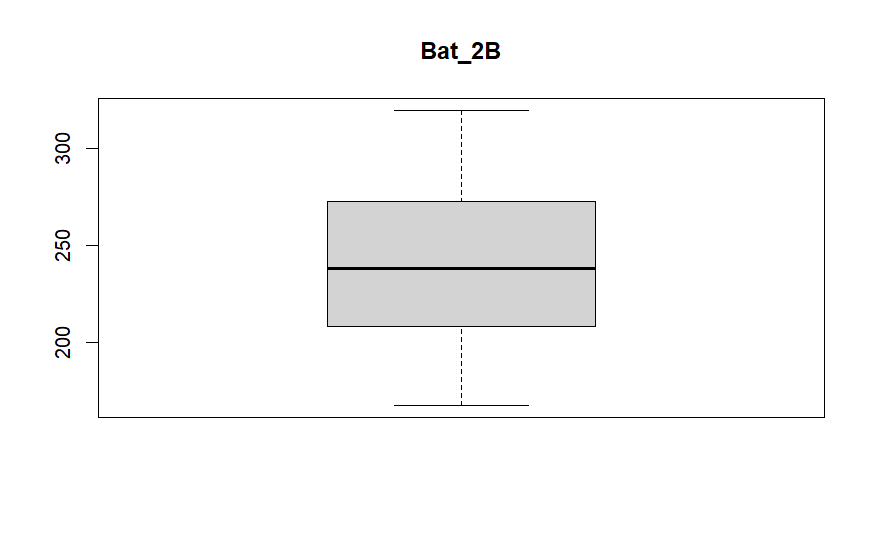

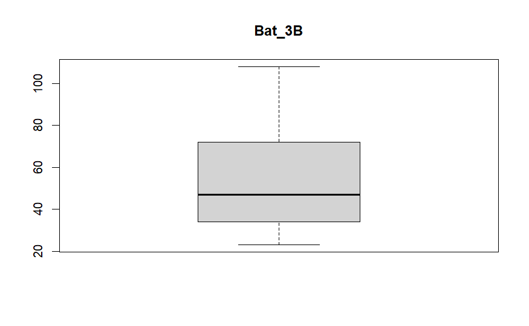

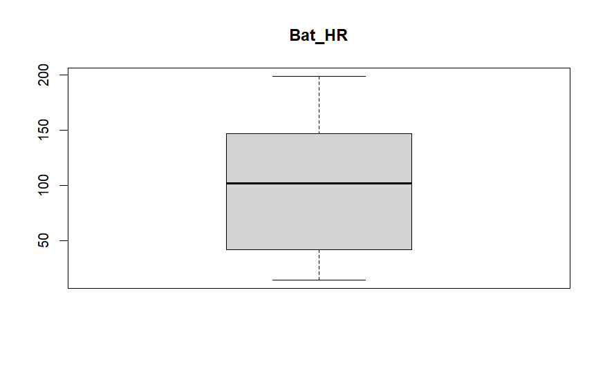

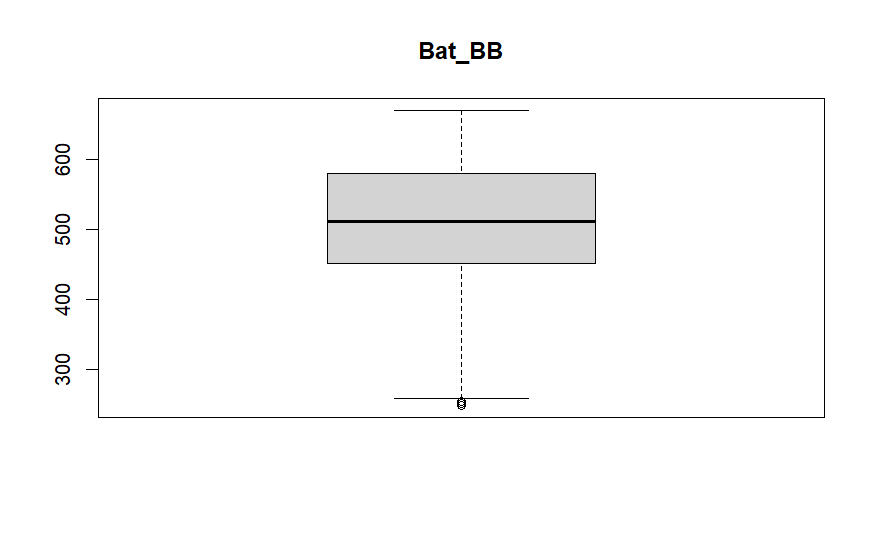

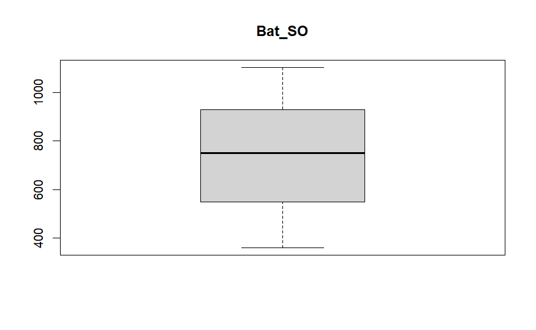

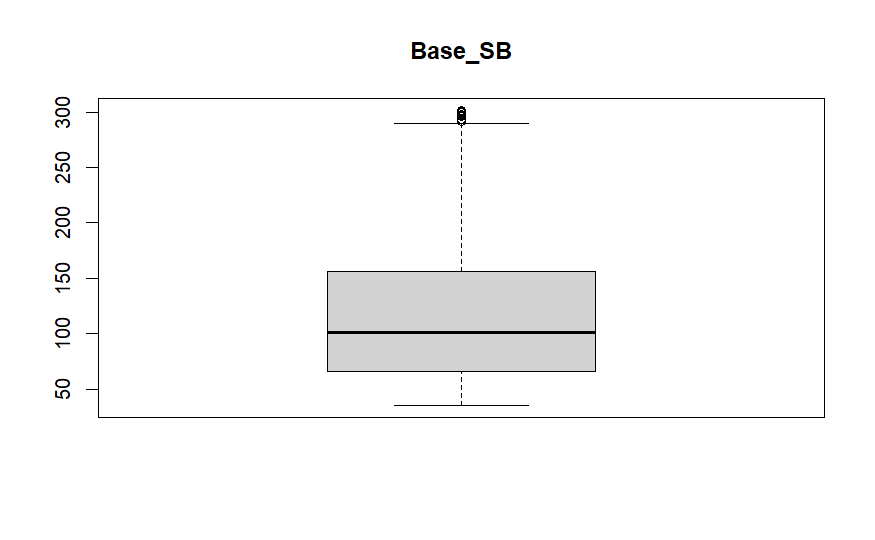

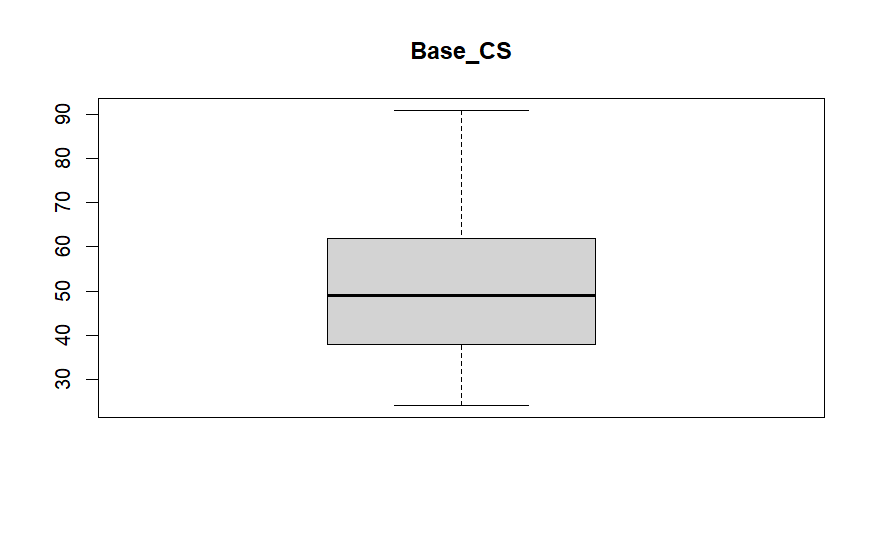

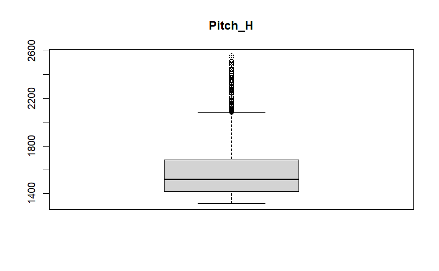

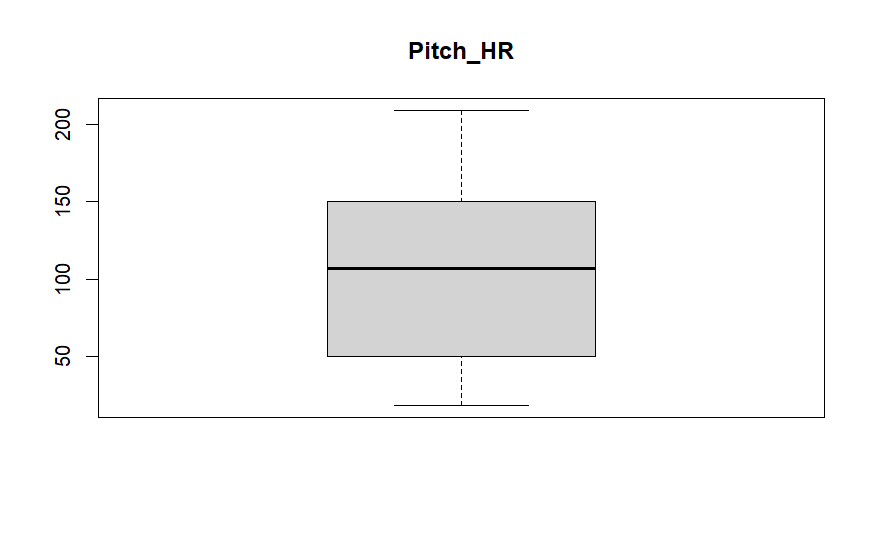

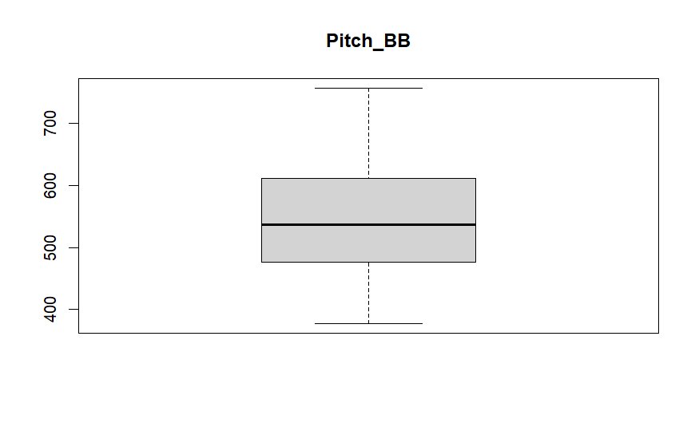

[3 more figures not shown]

```r
for (col_name in names(train_winsor)) {

  boxplot(train_winsor[[col_name]], main = col_name)

}
```

```r
summary(train_winsor)
```

```
      Wins            Bat_H          Bat_2B        Bat_3B           Bat_HR           Bat_BB          Bat_SO
 Min.   :  0.00   Min.   : 891   Min.   :167   Min.   : 23.00   Min.   : 14.00   Min.   :248.2   Min.   : 359.0
 1st Qu.: 71.00   1st Qu.:1383   1st Qu.:208   1st Qu.: 34.00   1st Qu.: 42.00   1st Qu.:451.0   1st Qu.: 548.0
 Median : 82.00   Median :1454   Median :238   Median : 47.00   Median :102.00   Median :512.0   Median : 750.0
 Mean   : 80.79   Mean   :1469   Mean   :241   Mean   : 54.59   Mean   : 98.88   Mean   :504.1   Mean   : 740.3
 3rd Qu.: 92.00   3rd Qu.:1537   3rd Qu.:273   3rd Qu.: 72.00   3rd Qu.:147.00   3rd Qu.:580.0   3rd Qu.: 930.0
 Max.   :146.00   Max.   :2554   Max.   :320   Max.   :108.00   Max.   :199.00   Max.   :670.2   Max.   :1103.3
                                                                                                 NA's   :102
    Base_SB         Base_CS         Pitch_H        Pitch_HR        Pitch_BB        Pitch_SO         Field_E
 Min.   : 35.0   Min.   :24.00   Min.   :1316   Min.   : 18.0   Min.   :377.0   Min.   : 421.3   Min.   :100.0
 1st Qu.: 66.0   1st Qu.:38.00   1st Qu.:1419   1st Qu.: 50.0   1st Qu.:476.0   1st Qu.: 615.0   1st Qu.:127.0
 Median :101.0   Median :49.00   Median :1518   Median :107.0   Median :536.5   Median : 813.5   Median :159.0
 Mean   :120.5   Mean   :51.56   Mean   :1617   Mean   :104.8   Mean   :546.9   Mean   : 796.7   Mean   :232.0
 3rd Qu.:156.0   3rd Qu.:62.00   3rd Qu.:1682   3rd Qu.:150.0   3rd Qu.:611.0   3rd Qu.: 968.0   3rd Qu.:249.2
 Max.   :301.8   Max.   :91.00   Max.   :2563   Max.   :209.2   Max.   :757.0   Max.   :1173.0   Max.   :716.0
 NA's   :131     NA's   :772                                                    NA's   :102
    Field_DP
 Min.   : 98.0
 1st Qu.:131.0
 Median :149.0
 Mean   :146.5
 3rd Qu.:164.0
 Max.   :186.0
 NA's   :286
```

```r
summary(train_cleaned)
```

```
      Wins            Bat_H          Bat_2B          Bat_3B           Bat_HR           Bat_BB
 Min.   :  0.00   Min.   : 891   Min.   : 69.0   Min.   :  0.00   Min.   :  0.00   Min.   :  0.0
 1st Qu.: 71.00   1st Qu.:1383   1st Qu.:208.0   1st Qu.: 34.00   1st Qu.: 42.00   1st Qu.:451.0
 Median : 82.00   Median :1454   Median :238.0   Median : 47.00   Median :102.00   Median :512.0
 Mean   : 80.79   Mean   :1469   Mean   :241.2   Mean   : 55.25   Mean   : 99.61   Mean   :501.6
 3rd Qu.: 92.00   3rd Qu.:1537   3rd Qu.:273.0   3rd Qu.: 72.00   3rd Qu.:147.00   3rd Qu.:580.0
 Max.   :146.00   Max.   :2554   Max.   :458.0   Max.   :223.00   Max.   :264.00   Max.   :878.0

     Bat_SO          Base_SB         Base_CS         Pitch_H         Pitch_HR        Pitch_BB
 Min.   :   0.0   Min.   :  0.0   Min.   :  0.0   Min.   : 1137   Min.   :  0.0   Min.   :   0.0
 1st Qu.: 548.0   1st Qu.: 66.0   1st Qu.: 38.0   1st Qu.: 1419   1st Qu.: 50.0   1st Qu.: 476.0
 Median : 750.0   Median :101.0   Median : 49.0   Median : 1518   Median :107.0   Median : 536.5
 Mean   : 735.6   Mean   :124.8   Mean   : 52.8   Mean   : 1779   Mean   :105.7   Mean   : 553.0
 3rd Qu.: 930.0   3rd Qu.:156.0   3rd Qu.: 62.0   3rd Qu.: 1682   3rd Qu.:150.0   3rd Qu.: 611.0
 Max.   :1399.0   Max.   :697.0   Max.   :201.0   Max.   :30132   Max.   :343.0   Max.   :3645.0
 NA's   :102      NA's   :131     NA's   :772
    Pitch_SO          Field_E          Field_DP
 Min.   :    0.0   Min.   :  65.0   Min.   : 52.0
 1st Qu.:  615.0   1st Qu.: 127.0   1st Qu.:131.0
 Median :  813.5   Median : 159.0   Median :149.0
 Mean   :  817.7   Mean   : 246.5   Mean   :146.4
 3rd Qu.:  968.0   3rd Qu.: 249.2   3rd Qu.:164.0
 Max.   :19278.0   Max.   :1898.0   Max.   :228.0
 NA's   :102                        NA's   :286
```

## Checking 0 Values

Since only one row has a 0 value, and it is in the Wins column. It will be left in the dataset as it seems a possible value.

|  | Wins | Bat_H | Bat_2B | Bat_3B | Bat_HR | Bat_BB | Bat_SO | Base_SB | Base_CS | Pitch_H | Pitch_HR | Pitch_BB | Pitch_SO | Field_E | Field_DP |
| --- | --- | --- | --- | --- | --- | --- | --- | --- | --- | --- | --- | --- | --- | --- | --- |
| 1211 | 0 | 891 | 167 | 23 | 14 | 248.25 | 359 | 35 | 24 | 2563 | 18 | 377 | 421.3 | 716 | NA |

## BoxCox Transformation

```r
preProcValues <- preProcess(train_winsor, method = "BoxCox")

trainBC <- predict(preProcValues, train_winsor)

preProcValues

trainBC
# Winsor Transformed: Bat_H, Bat_2B, Bat_3B, Bat_HR, Bat_BB, Bat_SO, Base_SB, Base_CS, Pitch_H, Pitch_HR, Pitch_BB, Pitch_SO, Field_E, Field_DP

# Non-Winsor cols_trans <- c("Bat_H","Bat_2B","Pitch_H","Field_E","Field_DP")
```

[output not shown]